# ggplot2 graphics companion

Last updated: 09 July 2020

The Graphics Companion provides the [R code](https://cran.r-project.org/) for different data visualisations that can be created using the [ggplot2 package](https://cran.r-project.org/web/packages/ggplot2/index.html).

The Companion adopts the structure of the [Financial Times’ Visual Vocabulary](https://ft.com/vocabulary) by categorising different chart types by the data relationships that they best illustrate.

The data used throughout the Companion derive from a subset of [Hans Rosling’s Gapminder World](https://www.gapminder.org/) which are available in the [gapminder R package](https://cran.r-project.org/web/packages/gapminder/index.html). Data on life expectancy at birth, GDP per capita and total population are provided for 142 countries between 1952 and 2007.

## Setup

You need to install - but only once - the [tidyverse package](https://www.tidyverse.org/) and load it into your R session. ggplot2 is part of the tidyverse suite of R tools for data science.

```r
# install.packages('tidyverse')
library(tidyverse)
```

All of the example plots below use data contained in the gapminder R package which also needs to be installed / loaded:

```r
# install.packages('gapminder')
library(gapminder)
```

Lastly, we need to load the [Trafford Data Lab’s ggplot2 theme](https://raw.githubusercontent.com/traffordDataLab/assets/601e80334e0d78dfe913685561196b8b6fc278a7/theme/ggplot2/theme_lab.R).

```r
source("https://raw.githubusercontent.com/traffordDataLab/assets/601e80334e0d78dfe913685561196b8b6fc278a7/theme/ggplot2/theme_lab.R")
```

If you wish to use an alternative theme simply swap out the `theme_lab()` function with a different [ggplot2 theme](http://ggplot2.tidyverse.org/reference/ggtheme.html) or use one from the [ggthemes package](https://cran.r-project.org/web/packages/ggthemes/index.html).

## Change over time

### Single line chart

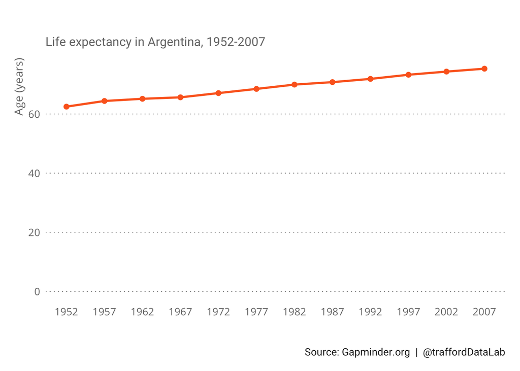

Life expectancy in Argentina, 1952-2007 single line chart.

```r
df <- filter(gapminder, country == "Argentina") %>%
  mutate(year = as.Date(paste(year, "-01-01", sep = "", format='%Y-%b-%d')))

ggplot(df, aes(x = year, y = lifeExp)) +
  geom_line(colour = "#fc6721", size = 1) +
  geom_point(colour = "#fc6721", size = 2) +
  scale_x_date(breaks = df$year, date_labels = "%Y") +
  scale_y_continuous(limits = c(0, max(df$lifeExp)), labels = scales::comma) +
  labs(title = "",
   subtitle = "Life expectancy in Argentina, 1952-2007",
   caption = "Source: Gapminder.org  |  @traffordDataLab",
   x = "",
   y = "Age (years)") +
  theme_lab() +
  theme(panel.grid.major.x = element_blank())
```

### Multiple line chart

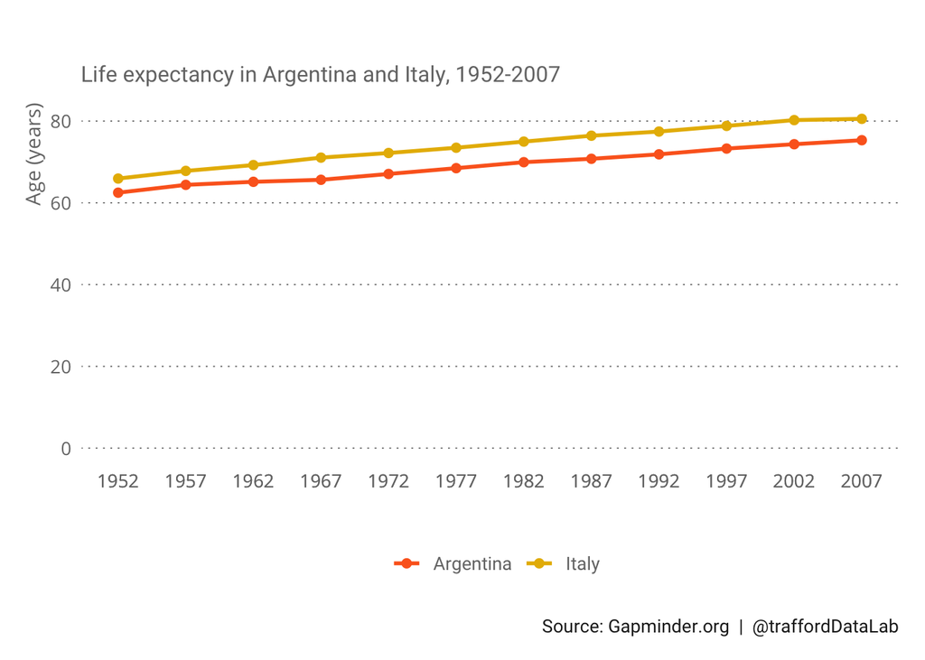

Life expectancy in Argentina and Italy, 1952-2007 multple line chart.

```r
df <- filter(gapminder, country %in% c("Argentina", "Italy")) %>%
  mutate(year = as.Date(paste(year, "-01-01", sep = "", format='%Y-%b-%d')))

ggplot(df, aes(x = year, y = lifeExp, colour = country)) +
  geom_line(size = 1) +
  geom_point(size = 2) +
  scale_colour_manual(values = c("Argentina" = "#fc6721", "Italy" = "#E7B800")) +
  scale_x_date(breaks = df$year, date_labels = "%Y") +
  scale_y_continuous(limits = c(0, NA), labels = scales::comma) +
  labs(title = "",
       subtitle = "Life expectancy in Argentina and Italy, 1952-2007",
       caption = "Source: Gapminder.org  |  @traffordDataLab",
       x = "",
       y = "Age (years)",
       colour = NULL) +
  theme_lab() +
  theme(panel.grid.major.x = element_blank(),
        legend.position = "bottom")
```

### Bar chart (vertical)

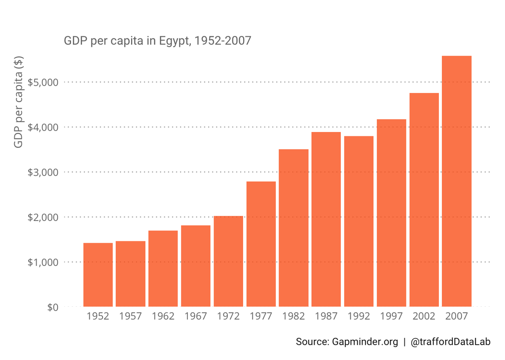

GDP per capita in Egypt, 1952-2007 vertical bar chart.

```r
df <- filter(gapminder, country == "Egypt") %>%
  mutate(year = as.Date(paste(year, "-01-01", sep = "", format='%Y-%b-%d')))

ggplot(df, aes(x = year, y = gdpPercap)) +
  geom_col(fill = "#fc6721", alpha = 0.8) +
  scale_x_date(breaks = df$year, date_labels = "%Y") +
  scale_y_continuous(expand = c(0, 0), labels = scales::dollar) +
  labs(title = "",
       subtitle = "GDP per capita in Egypt, 1952-2007", caption = "Source: Gapminder.org  |  @traffordDataLab",
       x = NULL,
       y = "GDP per capita ($)",
       fill = NULL) +
  theme_lab() +
  theme(panel.grid.major.x = element_blank())
```

### Slope chart

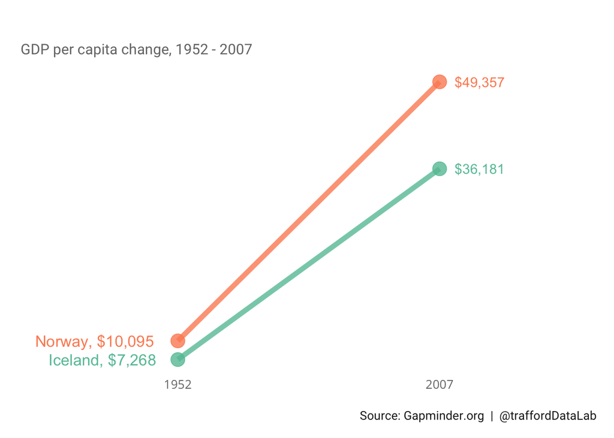

GDP per capita change, 1952-2007 slope chart.

```r
df <- filter(gapminder, country %in% c("Iceland", "Norway") & year %in% c(1952, 2007))

ggplot(df) +
  geom_line(aes(x = as.factor(year), y = gdpPercap, group = country, colour = country), size = 2, alpha = 0.8) +
  geom_point(aes(x = as.factor(year), y = gdpPercap, group = country, colour = country), size = 5, alpha = 0.8) +
  geom_text(data = subset(df, year == 1952),
            aes(x = as.factor(year), y = gdpPercap, colour = country,
                label = paste(country, scales::dollar(round(gdpPercap, 0)), sep = ", "),
            size = 4, hjust = 1.2)) +
  geom_text(data = subset(df, year == 2007),
            aes(x = as.factor(year), y = gdpPercap, colour = country, label = scales::dollar(round(gdpPercap, 0))),
            size = 4, hjust = -0.3) +
  scale_colour_brewer(palette = "Set2") +
  labs(title = "",
       subtitle = "GDP per capita change, 1952 - 2007",
       caption = "Source: Gapminder.org  |  @traffordDataLab",
       x = NULL,
       y = NULL,
       colour = NULL) +
  theme_lab() +
  theme(panel.grid.major = element_blank(),
        axis.text.y = element_blank(),
        legend.position = "none")
```

### Stacked area chart

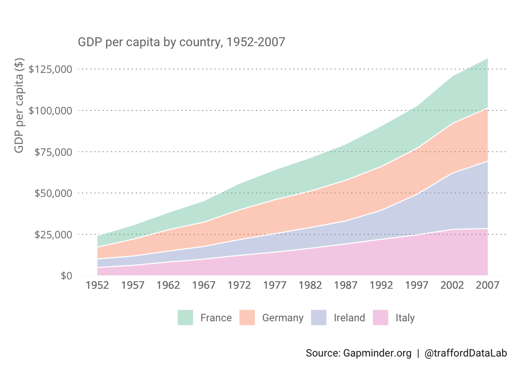

GDP per capita by country, 1952-2007 stacked area chart.

```r
df <- gapminder %>%
  filter(country %in% c("France", "Germany", "Ireland", "Italy")) %>%
  mutate(year = as.Date(paste(year, "-01-01", sep = "", format='%Y-%b-%d')))

ggplot(df, aes(x = year, y = gdpPercap, fill = country)) +
  geom_area(color = "white", alpha = 0.4) +
  scale_fill_brewer(palette = "Set2") +
  scale_x_date(breaks = df$year, date_labels = "%Y") +
  scale_y_continuous(expand = c(0, 0), labels = scales::dollar) +
  labs(title = "",
       subtitle = "GDP per capita by country, 1952-2007",
       caption = "Source: Gapminder.org  |  @traffordDataLab",
       x = NULL,
       y = "GDP per capita ($)",
       fill = NULL) +
  theme_lab() +
  theme(panel.grid.major.x = element_blank(),
        legend.position = "bottom")
```

## Correlation

### Scatterplot

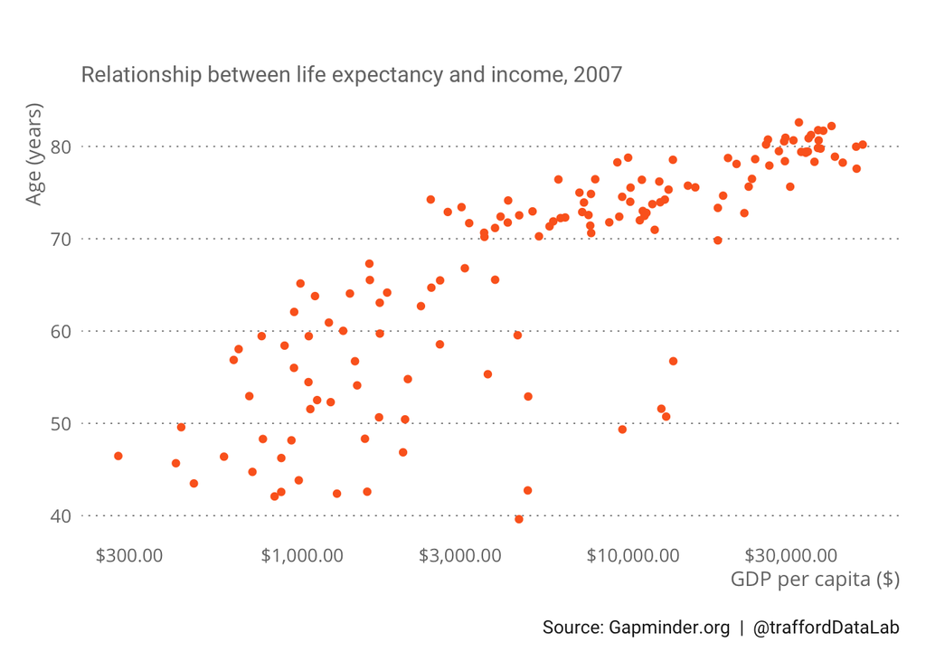

Relationship between life expectancy and income, 2007 scatterplot.

```r
ggplot(filter(gapminder, year == 2007), aes(x = gdpPercap, y = lifeExp)) +
  geom_point(colour = "#fc6721") +
  scale_x_log10(labels = scales::dollar) +
  labs(title = "",
       subtitle = "Relationship between life expectancy and income, 2007",
       caption = "Source: Gapminder.org  |  @traffordDataLab",
       x = "GDP per capita ($)",
       y = "Age (years)") +
  theme_lab() +
  theme(panel.grid.major.x = element_blank())
```

### Bubble chart

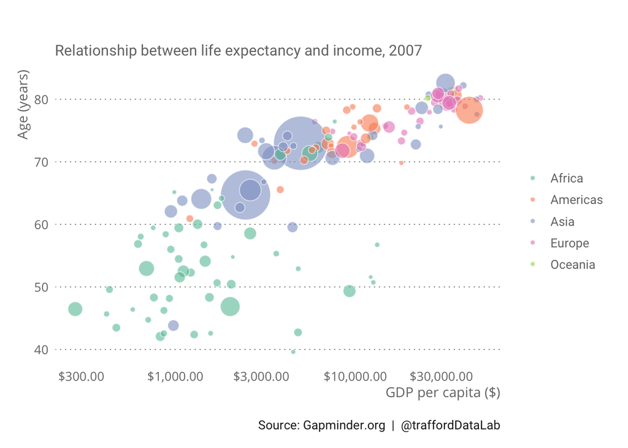

Relationship between life expectancy and income, 2007 bubble chart.

```r
ggplot(filter(gapminder, year == 2007), aes(x = gdpPercap, y = lifeExp)) +
  scale_x_log10(labels = scales::dollar) +
  geom_point(aes(size = pop, fill = continent), shape = 21, colour = "white", alpha = 0.6) +
  scale_fill_brewer(palette = "Set2") +
  scale_size_continuous(range = c(1, 20)) +
  labs(title = "",
       subtitle = "Relationship between life expectancy and income, 2007",
       caption = "Source: Gapminder.org  |  @traffordDataLab",
       x = "GDP per capita ($)",
       y = "Age (years)") +
  guides(size = FALSE) +
  theme_lab() +
  theme(panel.grid.major.x = element_blank(),
        legend.position = "right",
        legend.title = element_blank())
```

## Deviation

### Diverging bar chart

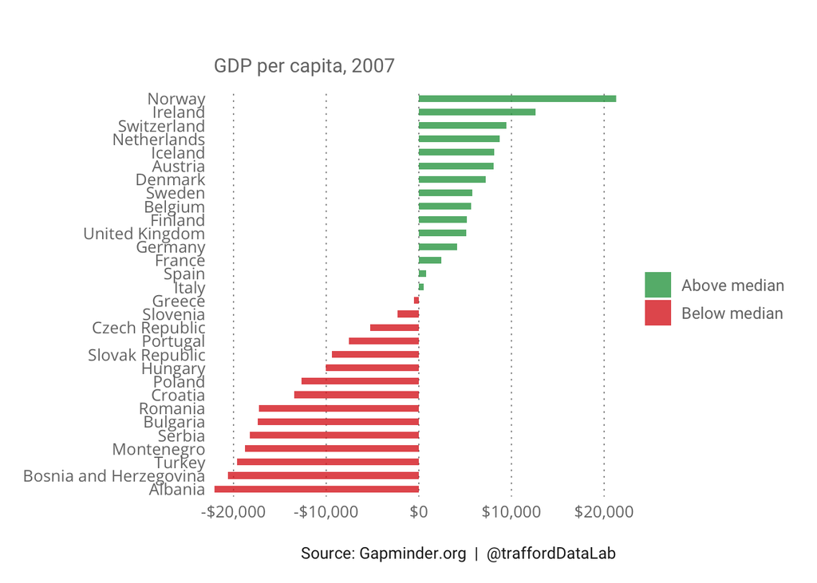

GDP per capita, 2007 diverging bar chart.

```r
df <- gapminder %>%
  filter(year == 2007 & continent == "Europe") %>%
  mutate(median = median(gdpPercap),
         diff = gdpPercap - median,
         type = ifelse(gdpPercap < median, "Below", "Above")) %>%
  arrange(diff) %>%
  mutate(country = factor(country, levels = country))

ggplot(df, aes(x = country, y = diff, label = country)) +
  geom_col(aes(fill = type), width = 0.5, alpha = 0.8)  +
  scale_y_continuous(expand = c(0, 0), labels = scales::dollar) +
  scale_fill_manual(labels = c("Above median", "Below median"),
                    values = c("Above" = "#31a354", "Below" = "#de2d26")) +
  labs(title = "",
       subtitle = "GDP per capita, 2007",
       caption = "Source: Gapminder.org  |  @traffordDataLab",
       x = NULL,
       y = NULL,
       fill = NULL) +
  coord_flip() +
  theme_lab() +
  theme(panel.grid.major.y = element_blank())
```

## Distribution

### Histogram

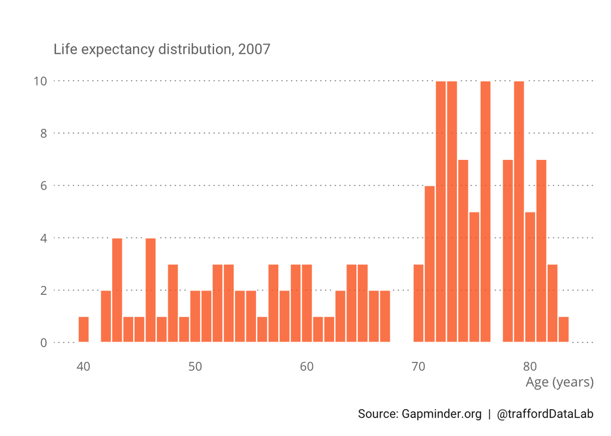

Life expectancy distribution, 2007 histogram.

```r
ggplot(filter(gapminder, year == 2007), aes(x = lifeExp)) +
  geom_histogram(binwidth = 1, fill = "#fc6721", colour = "white", alpha = 0.8) +
  scale_y_continuous(breaks = scales::pretty_breaks()) +
  labs(title = "",
       subtitle = "Life expectancy distribution, 2007",
       caption = "Source: Gapminder.org  |  @traffordDataLab",
       x = "Age (years)",
       y = "") +
  theme_lab() +
  theme(panel.grid.major.x = element_blank())
```

### Density plot

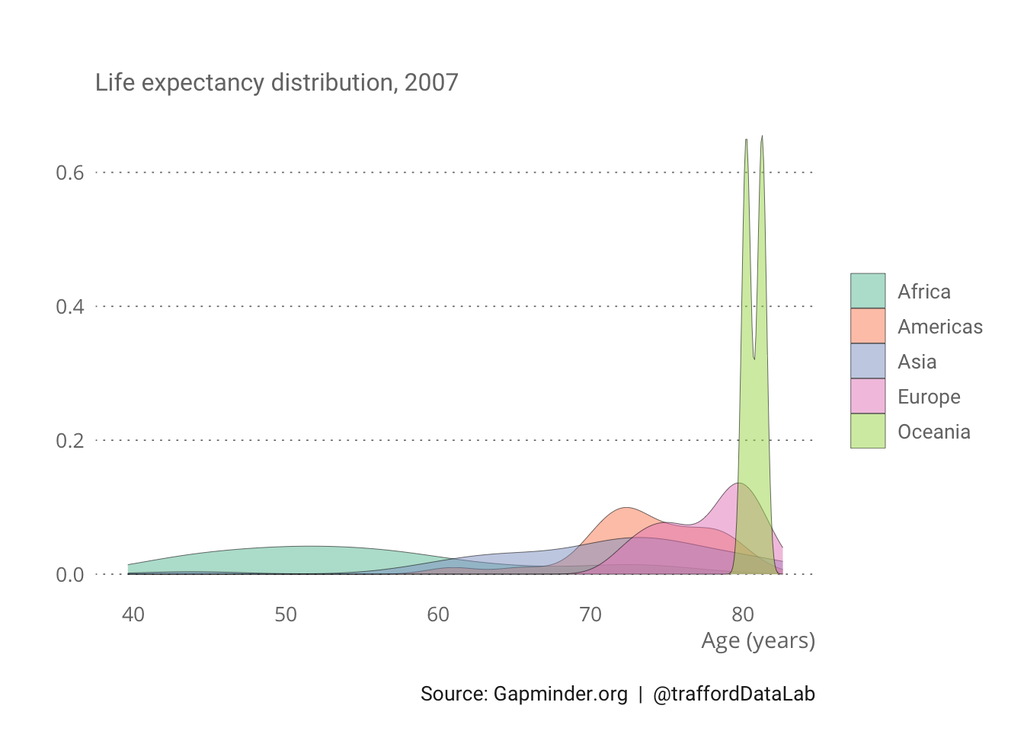

Life expectancy distribution, 2007 density plot.

```r
ggplot(filter(gapminder, year == 2007), aes(x = lifeExp)) +
  geom_density(aes(fill = continent), size = 0.1, alpha = 0.5) +
  scale_fill_brewer(palette = "Set2") +
  labs(title = "",
       subtitle = "Life expectancy distribution, 2007",
       caption = "Source: Gapminder.org  |  @traffordDataLab",
       x = "Age (years)",
       y = "",
       fill = NULL) +
  theme_lab() +
  theme(panel.grid.major.x = element_blank())
```

### Boxplot

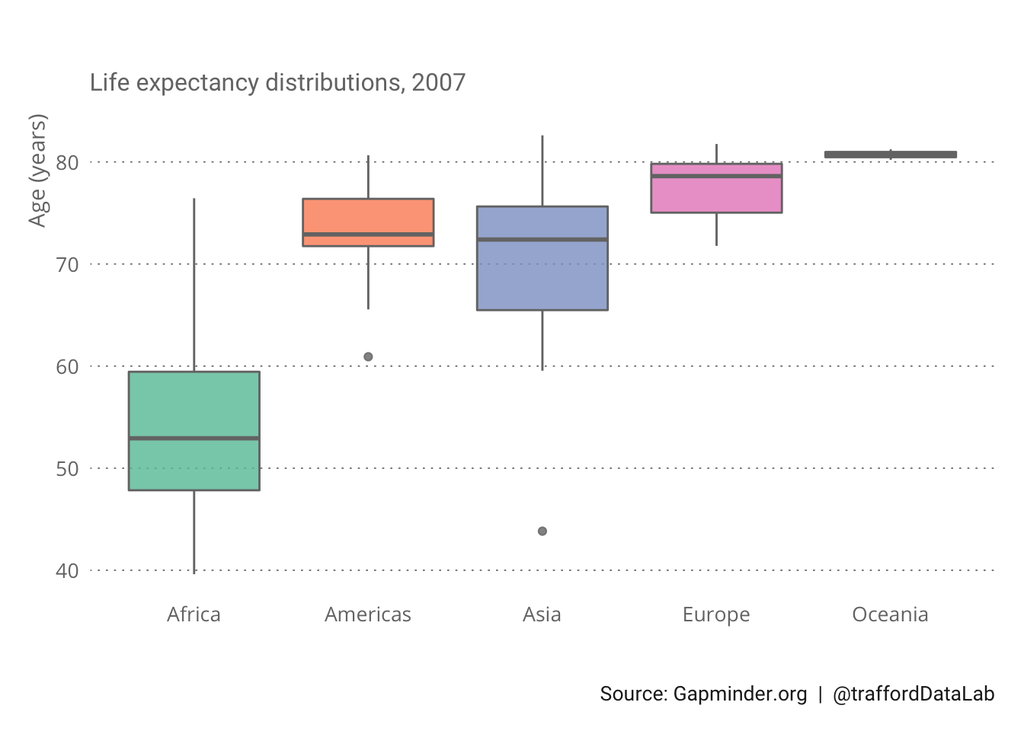

Life expectancy distribution, 2007 boxplot.

```r
ggplot(filter(gapminder, year == 2007), aes(x = continent, y = lifeExp, fill = continent)) +
  geom_boxplot(colour = "#757575", alpha = 0.8) +
  scale_fill_brewer(palette = "Set2") +
  labs(title = "",
       subtitle = "Life expectancy distributions, 2007",
       caption = "Source: Gapminder.org  |  @traffordDataLab",
       x = "",
       y = "Age (years)") +
  theme_lab() +
  theme(panel.grid.major.x = element_blank(),
        legend.position = "none")
```

### Violin plot

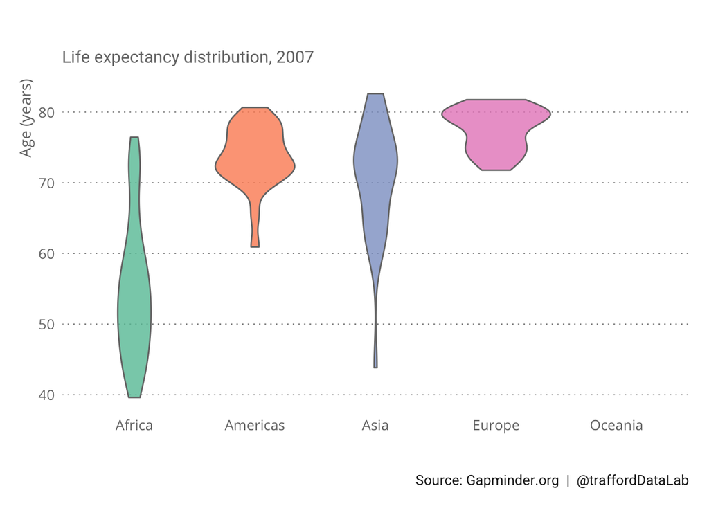

Life expectancy distribution, 2007 violin plot.

```r
ggplot(filter(gapminder, year == 2007), aes(x = continent, y = lifeExp, fill = continent)) +
  geom_violin(colour = "#757575", alpha = 0.8) +
  scale_fill_brewer(palette = "Set2") +
  labs(title = "",
       subtitle = "Life expectancy distribution, 2007",
       caption = "Source: Gapminder.org  |  @traffordDataLab",
       x = "",
       y = "Age (years)") +
  theme_lab() +
  theme(panel.grid.major.x = element_blank(),
        legend.position = "none")
```

### Ridgeline plot

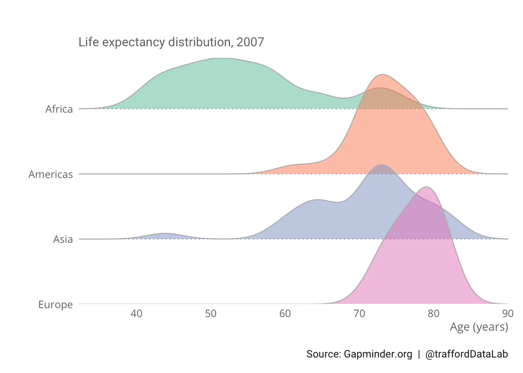

Life expectancy distribution, 2007 ridgeline plot.

```r
library(ggridges)
df <- gapminder %>% filter(year == 2007 & continent != "Oceania")

ggplot(df, aes(x = lifeExp, y = fct_rev(continent), fill = continent)) +
  geom_density_ridges(colour = "#bdbdbd", size = 0.5, alpha = 0.5) +
  scale_x_continuous(expand = c(0,0)) +
  scale_y_discrete(expand = c(0,0)) +
  scale_fill_brewer(palette = "Set2") +
  labs(title = "",
       subtitle = "Life expectancy distribution, 2007",
       caption = "Source: Gapminder.org  |  @traffordDataLab",
       x = "Age (years)",
       y = "") +
  theme_lab() +
  theme(panel.grid.major.x = element_blank(),
        legend.position = "none")
```

## Magnitude

### Bar chart (vertical)

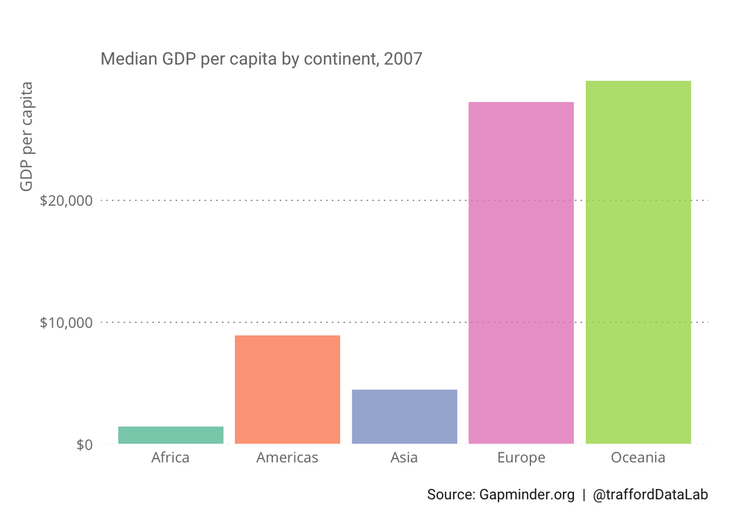

Median GDP per capita by continent, 2007 vertical bar chart.

```r
df <- gapminder %>%
      filter(year == 2007) %>%
      group_by(continent) %>%
      summarise(median = median(gdpPercap))

ggplot(df, aes(x = continent, y = median, fill = continent)) +
  geom_col(alpha = 0.8) +
  scale_fill_brewer(palette = "Set2") +
  scale_y_continuous(labels = scales::dollar, expand = c(0, 0)) +
  labs(title = "",
       subtitle = "Median GDP per capita by continent, 2007",
       caption = "Source: Gapminder.org  |  @traffordDataLab",
       x = NULL,
       y = "GDP per capita",
       fill = NULL) +
  theme_lab() +
  theme(panel.grid.major.x = element_blank(),
        legend.position = "none")
```

### Grouped bar chart

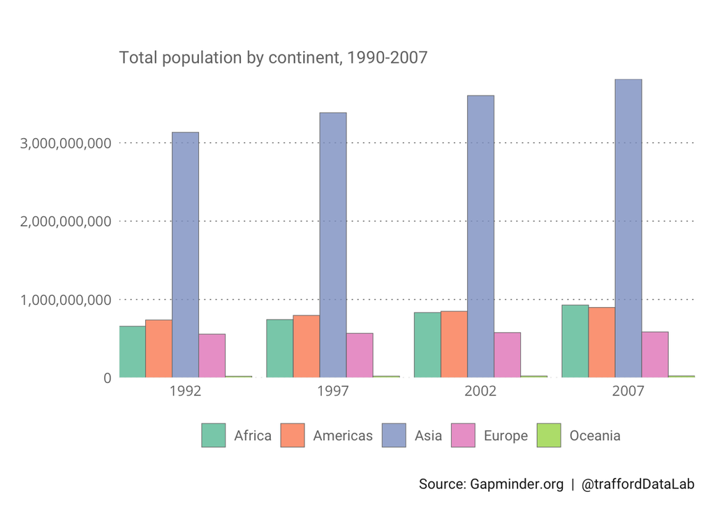

Total population by continent, 1990-2007 grouped bar chart.

```r
df <- gapminder %>%
  filter(year > 1990) %>%
  group_by(year, continent) %>%
  summarise(totalpop = sum(as.double(pop)))

ggplot(df, aes(x = year, y = totalpop, group = continent, fill = continent)) +
  geom_col(position = "dodge", colour = "#757575", size = 0.2, alpha = 0.8) +
  scale_x_continuous(breaks = seq(1992, 2007, 5), expand = c(0, 0)) +
  scale_y_continuous(labels = scales::comma, expand = c(0, 0)) +
  scale_fill_brewer(palette = "Set2") +
  labs(title = "",
       subtitle = "Total population by continent, 1990-2007",
       caption = "Source: Gapminder.org  |  @traffordDataLab",
       x = NULL,
       y = NULL,
       fill = NULL) +
  theme_lab() +
  theme(panel.grid.major.x = element_blank(),
        legend.position = "bottom")
```

### Stacked bar chart

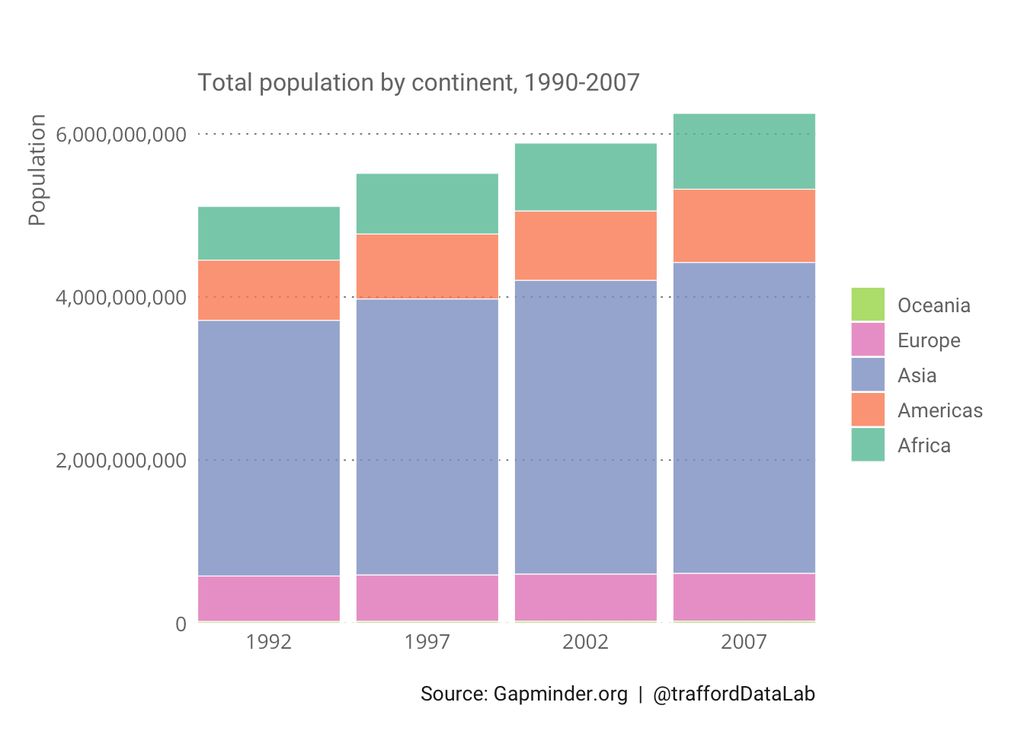

Total population by continent, 1990-2007 stacked bar chart.

```r
df <- gapminder %>%
  filter(year > 1990) %>%
  group_by(year, continent) %>%
  summarise(totalpop = sum(as.double(pop)))

ggplot(df, aes(x = year, y = totalpop, fill = continent)) +
  geom_col(colour = "white", size = 0.2, alpha = 0.8) +
  scale_x_continuous(breaks = seq(1992, 2007, 5), expand = c(0, 0)) +
  scale_y_continuous(labels = scales::comma, expand = c(0, 0)) +
  scale_fill_brewer(palette = "Set2") +
  guides(fill = guide_legend(reverse = T)) +
  labs(title = "",
       subtitle = "Total population by continent, 1990-2007",
       caption = "Source: Gapminder.org  |  @traffordDataLab",
       x = NULL,
       y = "Population",
       fill = NULL) +
  theme_lab() +
  theme(panel.grid.major.x = element_blank(),
        legend.position = "right")
```

## Part-to-whole

### 100% stacked bar chart

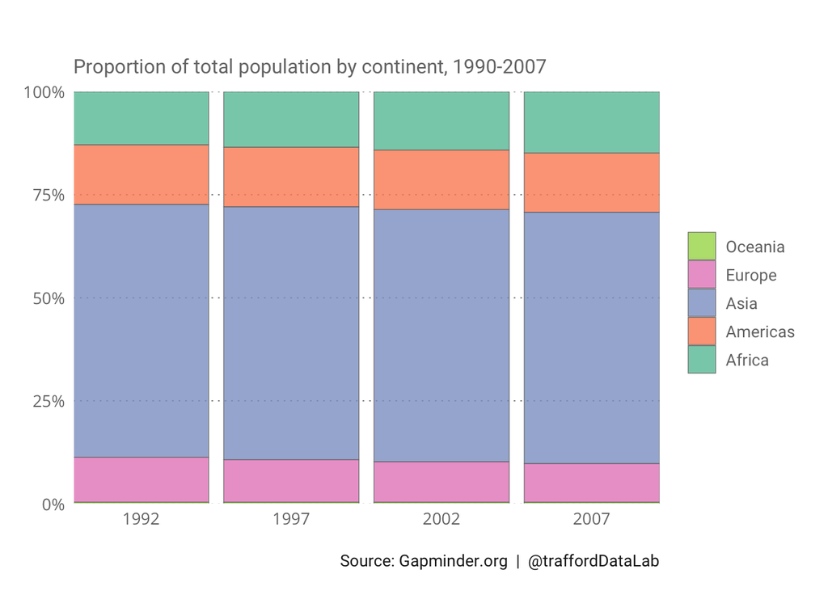

Proportion of total population by continent, 1990-2007 100% stacked bar chart.

```r
df <- gapminder %>%
  filter(year > 1990) %>%
  group_by(year, continent) %>%
  summarise(totalpop = sum(as.double(pop)))

ggplot(df, aes(x = year, y = totalpop, fill = continent)) +
  geom_col(position = "fill", colour = "#757575", size = 0.2, alpha = 0.8) +
  scale_x_continuous(breaks = seq(1992, 2007, 5), expand = c(0, 0)) +
  scale_y_continuous(labels = scales::percent, expand = c(0, 0)) +
  scale_fill_brewer(palette = "Set2") +
  guides(fill = guide_legend(reverse = T)) +
  labs(title = "",
       subtitle = "Proportion of total population by continent, 1990-2007",
       caption = "Source: Gapminder.org  |  @traffordDataLab",
       x = NULL,
       y = NULL,
       fill = NULL) +
  theme_lab() +
  theme(panel.grid.major.x = element_blank(),
        legend.position = "right")
```

### Treemap

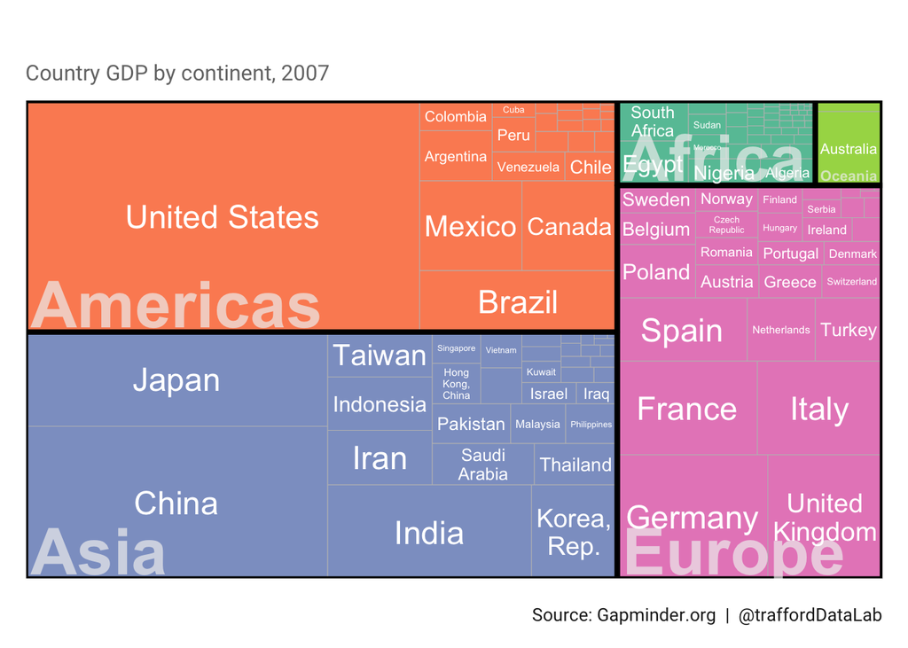

Country GDP by continent, 2007 treemap.

```r
library(treemapify)
df <- gapminder %>%
  filter(year == 2007) %>%
  mutate(gdp = pop * gdpPercap)

ggplot(df, aes(area = gdp, fill = continent, subgroup = continent, label = country)) +
  geom_treemap() +
  geom_treemap_subgroup_border(colour = "black") +
  geom_treemap_subgroup_text(fontface = "bold", colour = "#f0f0f0", alpha = 0.7, place = "bottomleft") +
  geom_treemap_text(colour = "white", place = "centre", reflow = TRUE) +
  scale_fill_brewer(palette = "Set2") +
  labs(title = "",
       subtitle = "Country GDP by continent, 2007",
       caption = "Source: Gapminder.org  |  @traffordDataLab",
       x = NULL,
       y = NULL,
       fill = NULL) +
  theme_lab() +
  theme(legend.position = "none")
```

### Waffle chart

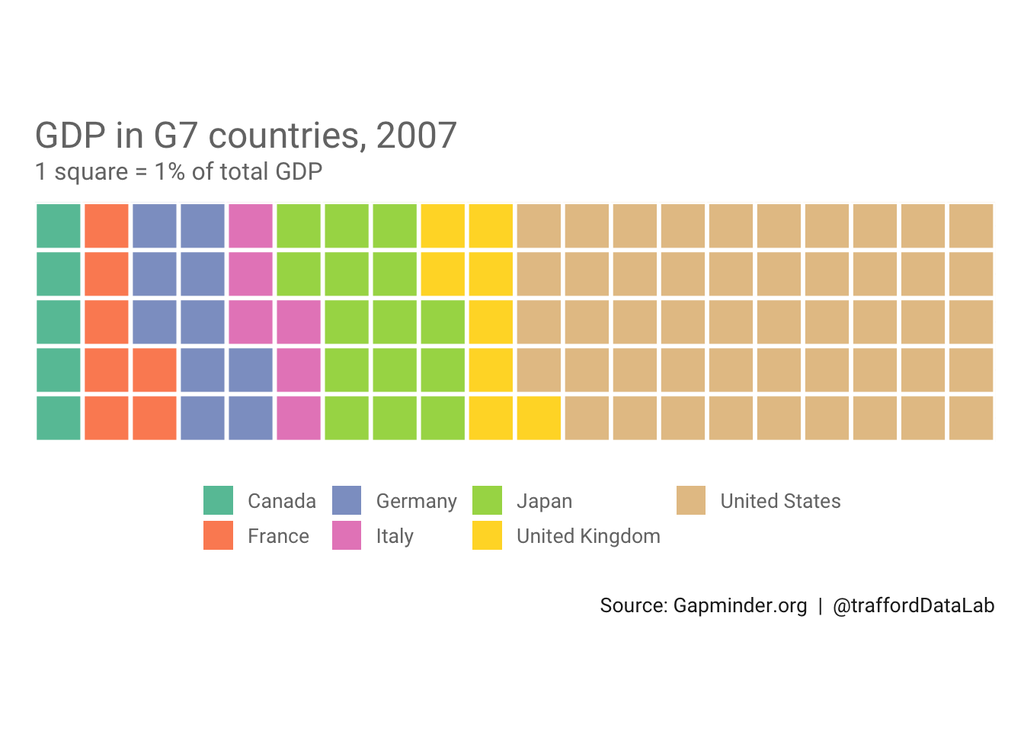

GDP in G7 countries, 2007 waffle chart.

```r
library(waffle) ; library(RColorBrewer)

g7 <- c("Canada", "France", "Germany", "Italy", "Japan", "United Kingdom", "United States")
df <- filter(gapminder, year == 2007 & country %in% g7) %>%
  mutate(gdp = pop * gdpPercap) %>%
  select(country, gdp)
vec <- magrittr::extract2(df, 'gdp') %>% set_names(df$country)

waffle(round((vec/sum(df$gdp)) * 100, 0), rows = 5, size = 1,
       colors = (brewer.pal(length(vec), "Set2"))) +
  labs(title = "GDP in G7 countries, 2007",
       subtitle = "1 square = 1% of total GDP",
       caption = "Source: Gapminder.org  |  @traffordDataLab",
       x = NULL,
       y = NULL,
       fill = NULL) +
  theme_lab() +
  theme(axis.text = element_blank(),
        legend.position = "bottom")
```

## Ranking

### Ordered bar chart (horizontal)

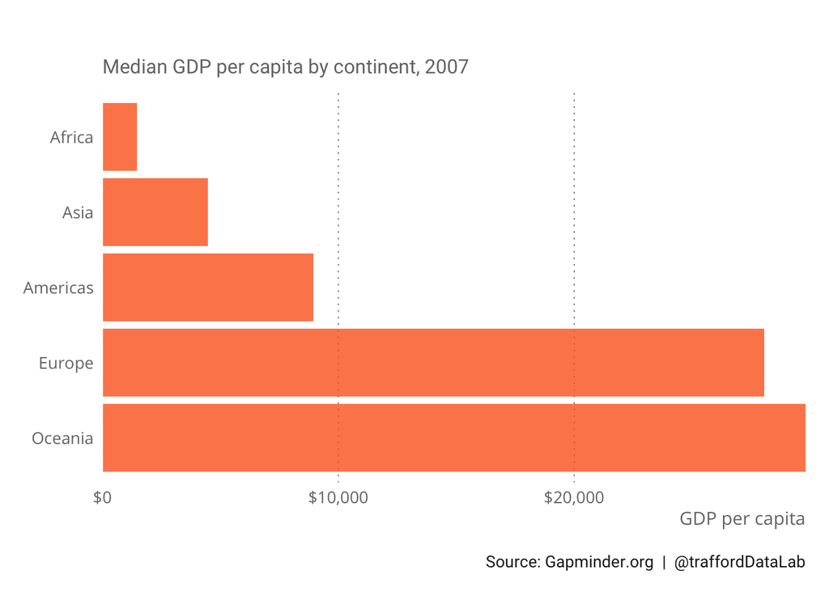

Median GDP per capita by continent, 2007 order bar chart.

```r
df <- gapminder %>%
  filter(year == 2007) %>%
  group_by(continent) %>%
  summarise(median = median(gdpPercap))

ggplot(df, aes(reorder(continent, -median, sum), median)) +
  geom_col(fill = "#fc6721", alpha = 0.8) +
  scale_y_continuous(expand = c(0, 0), labels = scales::dollar) +
  coord_flip() +
  labs(title = "",
       subtitle = "Median GDP per capita by continent, 2007",
       caption = "Source: Gapminder.org  |  @traffordDataLab",
       x = NULL,
       y = "GDP per capita",
       fill = NULL) +
  theme_lab() +
  theme(panel.grid.major.y = element_blank())
```

### Lollipop chart

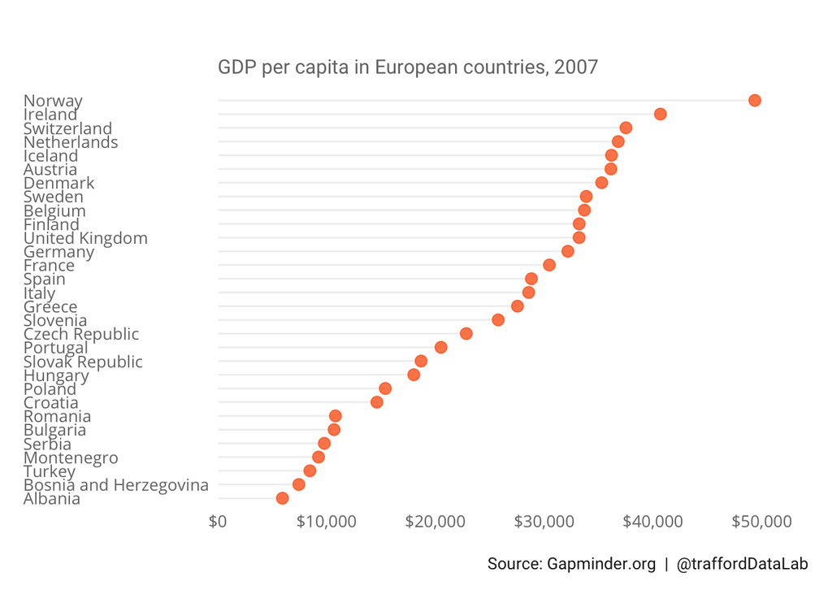

GDP per capita in European countries, 2007 lollipop chart.

```r
df <- gapminder %>%
  filter(year == 2007 & continent == "Europe") %>%
  arrange(gdpPercap) %>%
  mutate(country = factor(country, levels = country))

ggplot(df, aes(x = gdpPercap, y = country)) +
  geom_segment(aes(x = 0, xend = gdpPercap, y = country, yend = country), colour = "#f0f0f0") +
  geom_point(colour = "#fc6721", size = 3, alpha = 0.8) +
  scale_x_continuous(expand = c(0, 0), limits = c(0, max(df$gdpPercap) * 1.1),
                     labels = scales::dollar) +
  labs(title = "",
       subtitle = "GDP per capita in European countries, 2007",
       caption = "Source: Gapminder.org  |  @traffordDataLab",
       x = NULL,
       y = NULL,
       fill = NULL) +
  theme_lab() +
  theme(panel.grid.major = element_blank(),
        axis.text.y = element_text(hjust = 0))
```

## Spatial

### Choropleth map

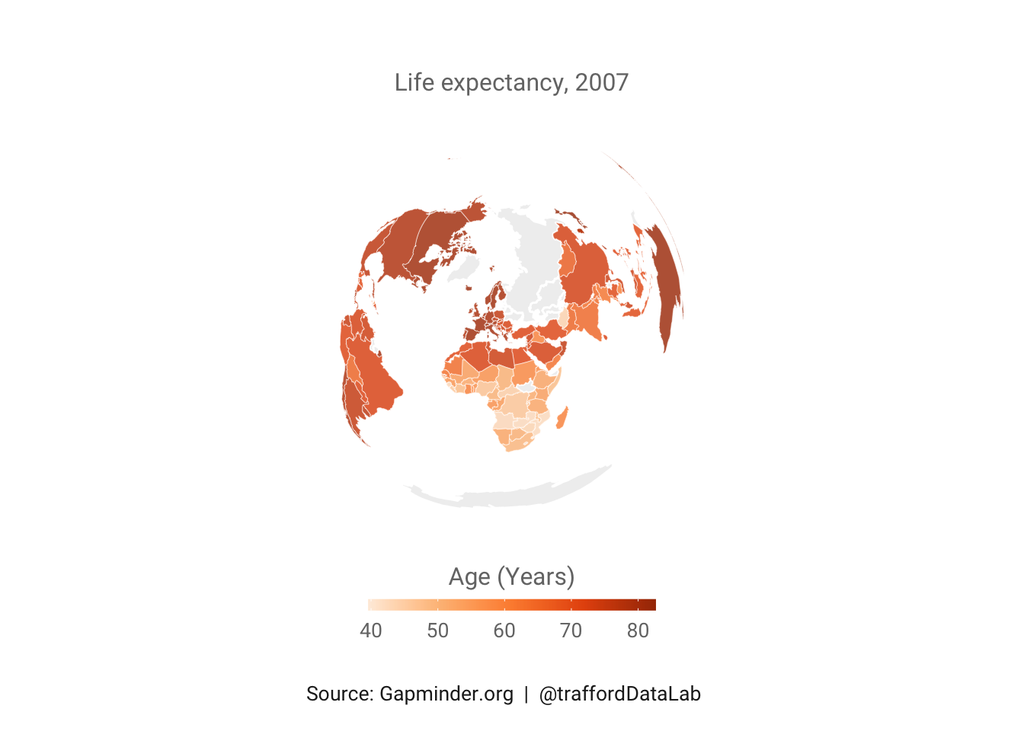

Life expectancy, 2007 choropleth map.

```r
df <- gapminder %>%
  filter(year == 2007) %>%
  left_join(country_codes) %>%
  rename("iso_a3" = "iso_alpha")

library(rnaturalearth)
world <- ne_countries(type = "countries",  returnclass = 'sf')
sf <- ne_countries(type = "countries",  returnclass = 'sf') %>%
  left_join(., df, by = "iso_a3", sort = FALSE) %>%
  filter(!is.na(country)) %>%
  select("country", "continent" = "continent.y", "year", "lifeExp", "pop", "gdpPercap", "geometry")

library(sf) ; library(RColorBrewer)
ggplot(sf, aes(fill = lifeExp)) +
  geom_sf(data = world, fill = "#f0f0f0", colour = "white") +
  geom_sf(alpha = 0.8, colour = "white", size = 0.1) +
  scale_fill_gradientn(colours = brewer.pal(5, "Oranges"),
                       name = "Age (Years)",
                       guide = guide_colourbar(
                         direction = "horizontal",
                         barheight = unit(2, units = "mm"),
                         barwidth = unit(50, units = "mm"),
                         title.position = 'top',
                         title.hjust = 0.5,
                         label.hjust = 0.5)) +
  labs(title = "",
       subtitle = "Life expectancy, 2007",
       caption = "Source: Gapminder.org  |  @traffordDataLab",
       x = NULL,
       y = NULL) +
  theme_lab() +
  theme(plot.title = element_text(hjust = 0.5),
        plot.subtitle = element_text(hjust = 0.5),
        legend.position = "bottom") +
  coord_sf(crs = "+proj=laea +lat_0=52 +lon_0=10 +x_0=4321000 +y_0=3210000
           +datum=WGS84 +units=m +no_defs",
           datum = NA)
```

## Useful resources

- Chang, W. (2012). *R Graphics Cookbook: Practical Recipes for Visualizing Data*. O’Reilly Media, Inc.
- Wickham, H., & Grolemund, G. (2016). *R for data science: import, tidy, transform, visualize, and model data*. O’Reilly Media, Inc. Available online via http://r4ds.had.co.nz/
- Wickham, H. (2016). *ggplot2: elegant graphics for data analysis*. Springer.
- [RStudio ggplot2 cheat sheet (PDF)](https://github.com/rstudio/cheatsheets/raw/master/data-visualization-2.1.pdf)